# SCGSR final report

2023-06-21

## Sample Summary

Soils from northwest Alaska were homogenized and pre-incubated at -2 and -6 degrees Celsius for three months after which they were incubated at 2,4,6,8,10 degrees Celsius for one week. After the week long incubation soils were extracted using 0.5M K2SO4, and chloroform extracted to measure microbial biomass and nutrient concentrations. Sub-samples were also sent to PNNL for MPLEx (Methanol chloroform extraction) to provide more comprehensive analysis of the molecular composition of organic matter using FT-ICR, NMR, GC-MS and LC-MS techniques. Lipidomics were also performed to ascertain if there were any significant shifts in microbial biomass.

## Respiration Results

Respiration measurements were taken daily during the incubation using a Li-850 bench top respiration unit. Below are the respiration rates for each sample, as well as the calculates total C respired. Linear mixed effects model showed significant respiration variation by incubation and pre incubation temperatures. An asterisks indicates a significant (p<= 0.05, ANOVA) difference in pre-incubation temperature.

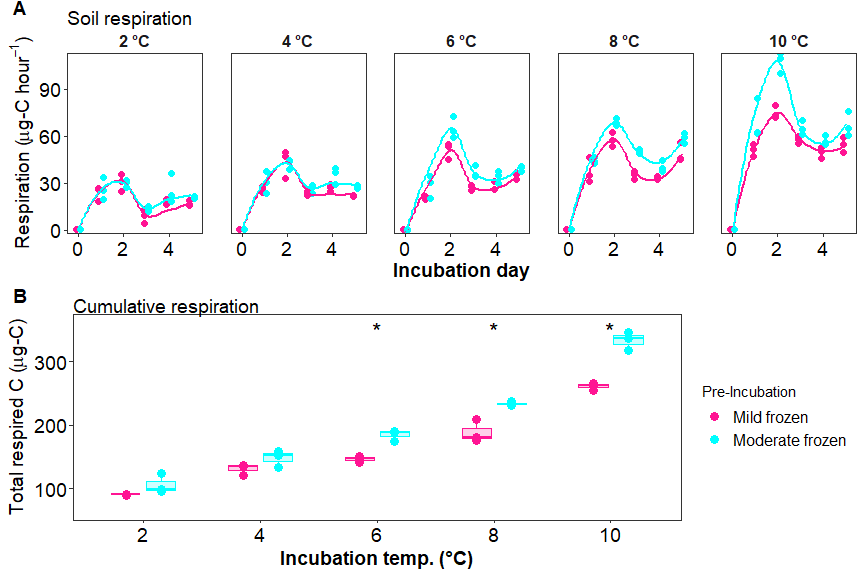

## Soil Nutrients

Soil K2SO4 extracts were utilized to measure ammonium, Nitrate, Total free primary amines, phosphate, Total reducing sugars. Below are the concentration data. An asterisks indicates a significant (p<= 0.05, ANOVA) difference in pre-incubation temperature.

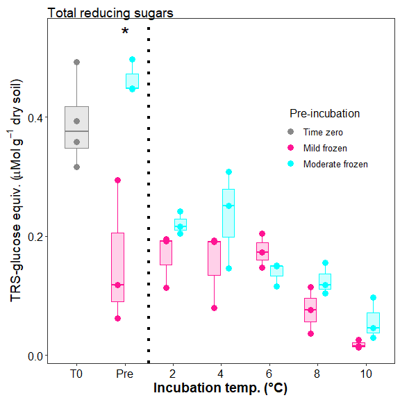

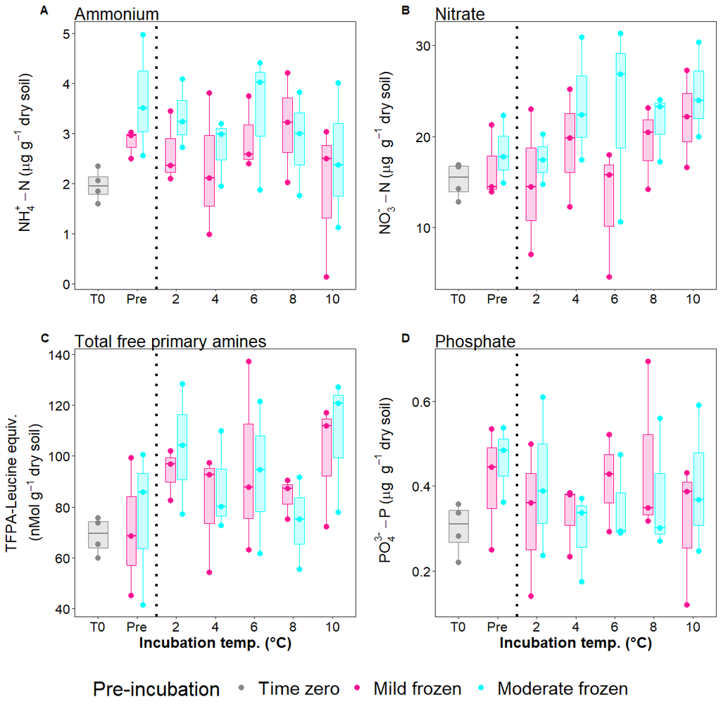

## Microbial Biomass

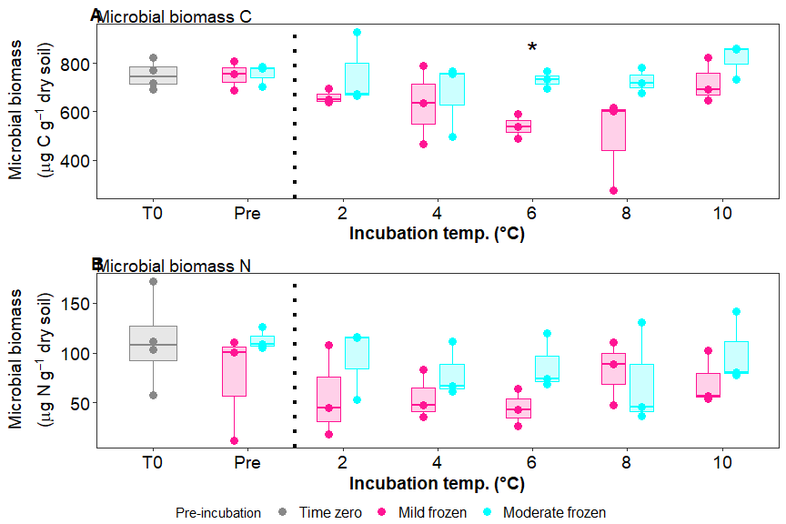

## GC-MS

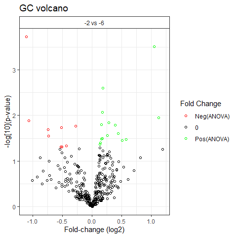

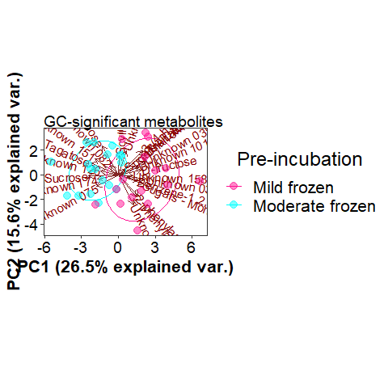

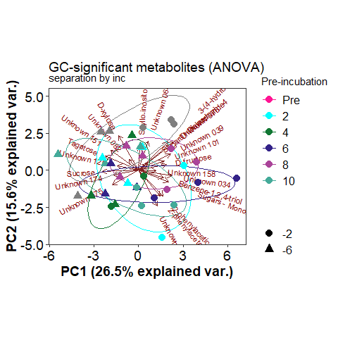

## LC-MS

Below is the relative quantification of compounds identified by liquid chromatography within the MPLEx extracts.Little to no variation was identified that corresponds to the more broad metrics above in the soil nutrient section. The majority of compounds measured were unidentified. Volcano plot can be used to identify the compounds that are significantly greater between pre incubation temperature (p<0.05, ANOVA). After which we used a PCA to visualize separation between the pre incubation temperatures across significantly different compounds. PERMANOVA results are displayed in the table below the PCAs to show variation between treatments.

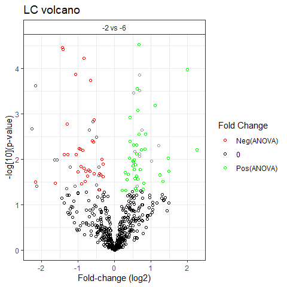

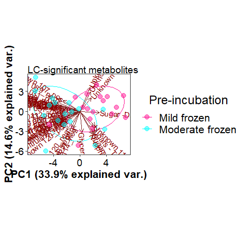

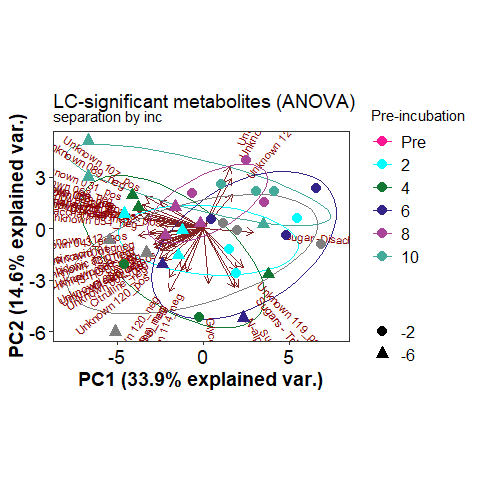

|  | Df | SumOfSqs | R2 | F | Pr(>F) |
| --- | --- | --- | --- | --- | --- |
| pre | 1 | 0.0025800 | 0.1596463 | 7.557022 | 0.001 |
| inc | 5 | 0.0032469 | 0.2009156 | 1.902109 | 0.018 |
| pre:inc | 5 | 0.0028229 | 0.1746759 | 1.653693 | 0.059 |
| Residual | 22 | 0.0075109 | 0.4647622 | NA | NA |
| Total | 33 | 0.0161607 | 1.0000000 | NA | NA |

Permanova results significant compounds only

## Lipids

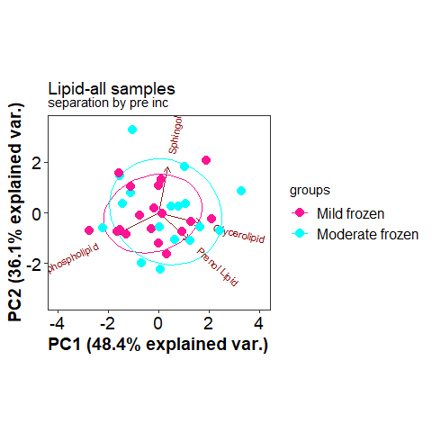

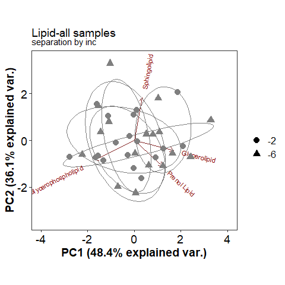

|  | Df | SumOfSqs | R2 | F | Pr(>F) |
| --- | --- | --- | --- | --- | --- |
| Pre | 1 | 0.0000141 | 0.0361871 | 1.375732 | 0.238 |
| Inc | 5 | 0.0000734 | 0.1882390 | 1.431265 | 0.207 |
| Pre:Inc | 5 | 0.0000665 | 0.1705848 | 1.297032 | 0.266 |
| Residual | 23 | 0.0002358 | 0.6049891 | NA | NA |
| Total | 34 | 0.0003897 | 1.0000000 | NA | NA |

Permanova results all

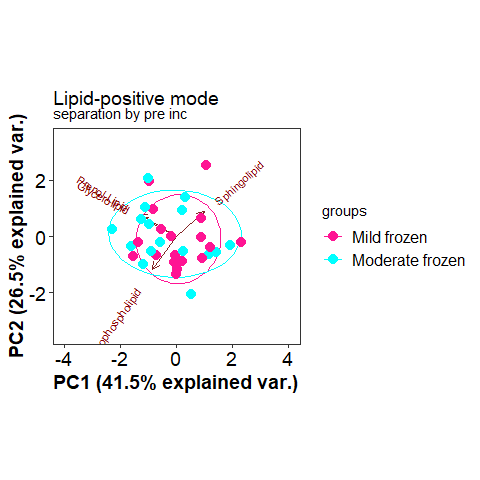

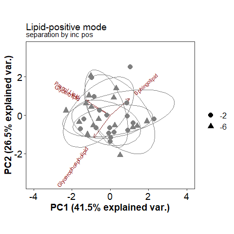

|  | Df | SumOfSqs | R2 | F | Pr(>F) |
| --- | --- | --- | --- | --- | --- |
| Pre | 1 | 0.0000047 | 0.0117707 | 0.4052875 | 0.704 |
| Inc | 5 | 0.0000655 | 0.1637689 | 1.1277753 | 0.374 |
| Pre:Inc | 5 | 0.0000626 | 0.1564754 | 1.0775498 | 0.398 |
| Residual | 23 | 0.0002672 | 0.6679850 | NA | NA |
| Total | 34 | 0.0003999 | 1.0000000 | NA | NA |

Permanova results pos

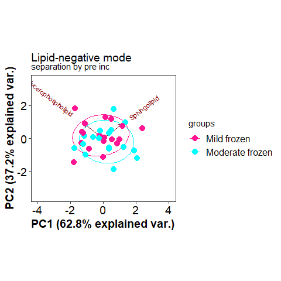

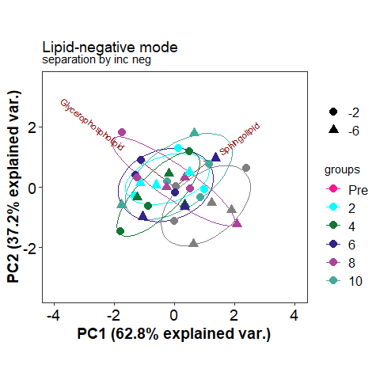

|  | Df | SumOfSqs | R2 | F | Pr(>F) |
| --- | --- | --- | --- | --- | --- |
| Pre | 1 | 0.0000364 | 0.0493385 | 2.557097 | 0.109 |
| Inc | 5 | 0.0002197 | 0.2975080 | 3.083825 | 0.016 |
| Pre:Inc | 5 | 0.0001546 | 0.2093743 | 2.170273 | 0.069 |
| Residual | 23 | 0.0003277 | 0.4437791 | NA | NA |
| Total | 34 | 0.0007384 | 1.0000000 | NA | NA |

Permanova results neg

## FT-MS (FT-ICR)

FTICR was performed on MEPLEx extracts to gain a qualitative understanding of the changes in organic matter composition after the incubation. There appear to be differences between pre-incubation temperatures, particularly in terms of the number of unique compounds, which could be indicative of microbial processing of organic matter and production of new organic compounds.

### FTICR Van krevelen diagrams:

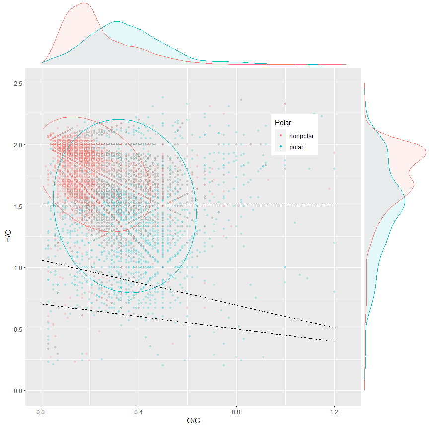

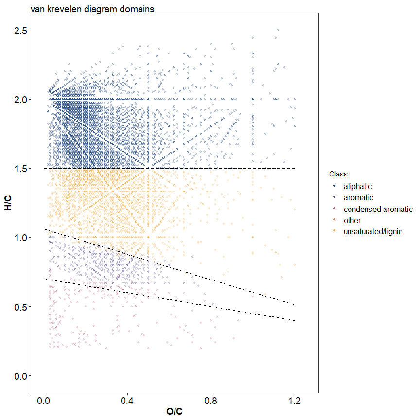

### FTICR Common vs unique peaks by treatment:

#### All

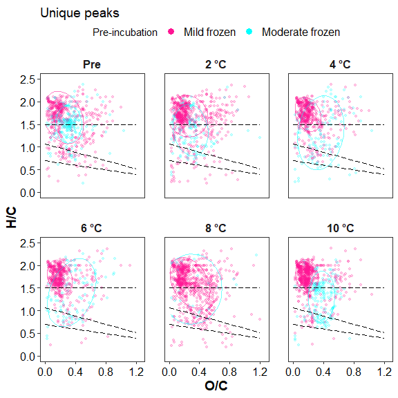

| Class | -2_Pre | -6_Pre | -2_2 | -6_2 | -2_4 | -6_4 | -2_6 | -6_6 | -2_8 | -6_8 | -2_10 | -6_10 |
| --- | --- | --- | --- | --- | --- | --- | --- | --- | --- | --- | --- | --- |
| aliphatic | 313 | 114 | 465 | 49 | 402 | 56 | 408 | 46 | 520 | 14 | 566 | 60 |
| aromatic | 34 | 13 | 18 | 16 | 21 | 14 | 13 | 18 | 48 | 3 | 21 | 35 |
| condensed aromatic | 15 | 2 | 27 | 3 | NA | 18 | 9 | 3 | 25 | NA | 7 | 9 |
| unsaturated/lignin | 85 | 79 | 86 | 54 | 69 | 42 | 57 | 27 | 166 | 9 | 69 | 75 |

Unique between preincubation temperatures at each incubation temperature

#### Polar

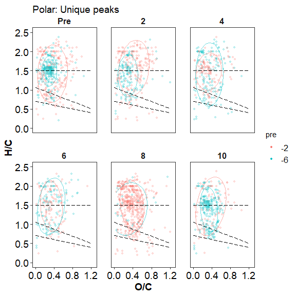

| Class | -2_Pre | -6_Pre | -2_2 | -6_2 | -2_4 | -6_4 | -2_6 | -6_6 | -2_8 | -6_8 | -2_10 | -6_10 |
| --- | --- | --- | --- | --- | --- | --- | --- | --- | --- | --- | --- | --- |
| aliphatic | 100 | 126 | 122 | 50 | 67 | 74 | 57 | 63 | 265 | 13 | 46 | 105 |
| aromatic | 28 | 14 | 10 | 17 | 12 | 14 | 8 | 20 | 42 | 3 | 10 | 38 |
| condensed aromatic | 13 | 3 | 18 | 3 | NA | 18 | 7 | 3 | 24 | NA | 4 | 10 |
| unsaturated/lignin | 67 | 84 | 42 | 60 | 45 | 43 | 31 | 28 | 142 | 9 | 28 | 84 |

Unique between preincubation temperatures at each incubation temperature polar

#### Non-Polar

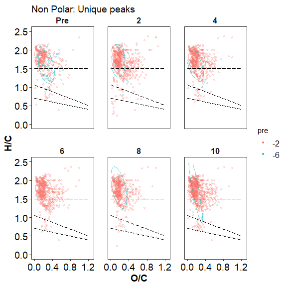

| Class | -2_Pre | -6_Pre | -2_2 | -6_2 | -2_4 | -6_4 | -2_6 | -6_6 | -2_8 | -6_8 | -2_10 | -6_10 |
| --- | --- | --- | --- | --- | --- | --- | --- | --- | --- | --- | --- | --- |
| aliphatic | 272 | 34 | 456 | 15 | 445 | 13 | 449 | 3 | 411 | 8 | 633 | 3 |
| aromatic | 13 | 1 | 13 | 1 | 14 | NA | 10 | NA | 11 | 1 | 20 | NA |
| condensed aromatic | 5 | NA | 11 | NA | 2 | NA | 3 | NA | 4 | NA | 4 | NA |
| unsaturated/lignin | 49 | 20 | 111 | 3 | 77 | 6 | 102 | NA | 68 | 2 | 116 | 1 |

Unique between preincubation temperatures at each incubation temperature nonpolar

### FTICR relative abundance and PCAs:

#### Relative Abundance

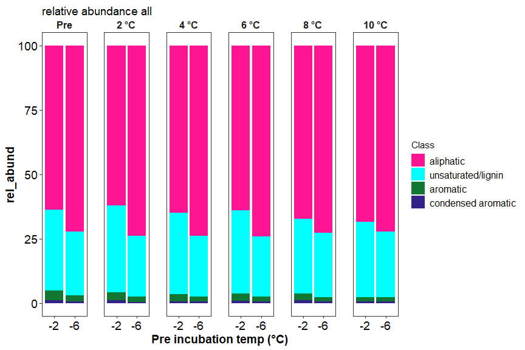

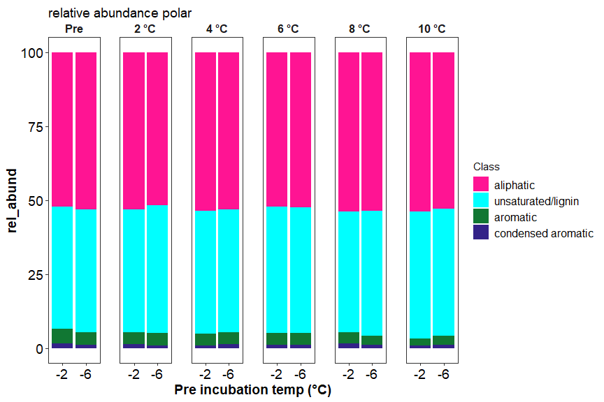

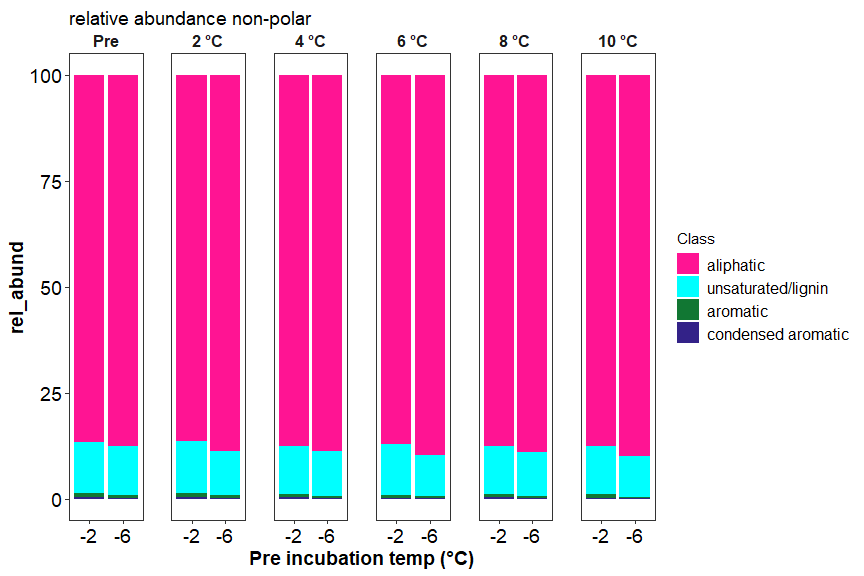

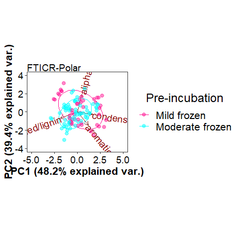

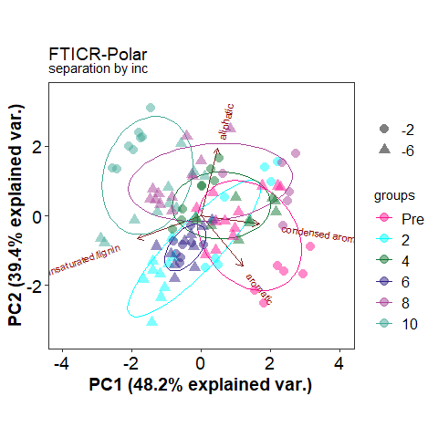

|  | Df | SumOfSqs | R2 | F | Pr(>F) |
| --- | --- | --- | --- | --- | --- |
| pre | 1 | 0.0004596 | 0.0321579 | 10.58298 | 0.001 |
| inc | 5 | 0.0066832 | 0.4676090 | 30.77754 | 0.001 |
| pre:inc | 5 | 0.0029803 | 0.2085238 | 13.72482 | 0.001 |
| Residual | 96 | 0.0041692 | 0.2917093 | NA | NA |
| Total | 107 | 0.0142922 | 1.0000000 | NA | NA |

Permanova results: Axis class Polar only

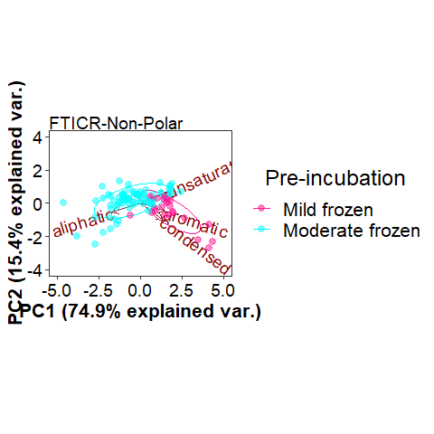

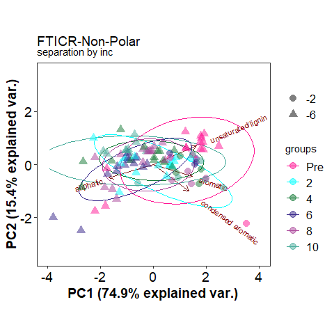

|  | Df | SumOfSqs | R2 | F | Pr(>F) |
| --- | --- | --- | --- | --- | --- |
| pre | 1 | 0.0050061 | 0.1717359 | 26.4653827 | 0.001 |
| inc | 5 | 0.0052433 | 0.1798715 | 5.5438239 | 0.001 |
| pre:inc | 5 | 0.0009308 | 0.0319305 | 0.9841303 | 0.429 |
| Residual | 95 | 0.0179699 | 0.6164622 | NA | NA |
| Total | 106 | 0.0291500 | 1.0000000 | NA | NA |

Permanova results: Axis class Non-Polar only

## Session Info

Date run: 2024-05-31